# `for` Loops

Author

Mark Nepf (mnepf@uw.edu)

Published

September 28, 2026

## Introduction

When working in R, you will often encounter situations where you need to perform the same task multiple times. For example, you might want to calculate the same statistic for several groups, apply the same transformation to multiple objects, or repeat an analysis using different inputs. Writing out the same code separately for every case can quickly become repetitive and difficult to maintain.

Loops provide a way to automate these repetitive tasks. A loop tells R to repeatedly execute a piece of code while changing the value being used each time. Rather than writing the same instructions over and over, you write them once and tell R which values you want to work through.

The goal of this vignette is to introduce the structure and logic of `for` loops in R and demonstrate how they can be used to automate repeated, multi-step tasks. We will begin by examining the basic components of a `for` loop, followed by more advanced applications, including nested loops, storing results, and repeatedly fitting models for different groups.

Finally, we will consider when a `for` loop is useful compared with vectorized or grouped approaches. By the end, you should be able to understand how `for` loops work, construct loops for your own analyses, and recognize situations where looping can make a repeated procedure easier to automate and manage.

### R Packages

You will need the following R packages. If you have already installed them, skip the `install.packages` lines.

```r
# install
install.packages("tidyverse")  # cleaning data
install.packages("gt")  # creating tables
```

```r
# load
library(tidyverse)
library(gt)
```

## `for` Loops

One of the most common types of loops is a `for` loop. `for` loops tell R to repeat the same piece of code *for* multiple items or values. We simply provide R with the code to be looped through and the collection of items (e.g., names) or values (e.g., years) to be iteratively passed through that code.

For example, suppose you want R to print each of the following numbers:

```r
10
20
30
40
50
```

You could write five separate `print` statements:

```r
print(10)
```

```
[1] 10
```

```r
print(20)
```

```
[1] 20
```

```r
print(30)
```

```
[1] 30
```

```r
print(40)
```

```
[1] 40
```

```r
print(50)
```

```
[1] 50
```

But this becomes inefficient when there are many values or when the code you want to repeat is more complicated.

A `for` loop allows you to accomplish the same task with a single line of code:

```r
for (number in c(10, 20, 30, 40, 50)) {print(number)}
```

```
[1] 10
[1] 20
[1] 30
[1] 40
[1] 50
```

The loop tells R: *for each number in the collection c(10, 20, 30, 40, 50), print that number*

The basic idea is simple, but understanding how each part of the loop works is important before using loops for more complicated tasks.

### Basic Structure

A `for` loop has the following general structure:

```r
for (item in vector) {code_to_repeat}
```

where:

1. `for` tells R that you are creating a loop
2. `item` is an index variable that represents the current item in the loop
3. `vector` is the collection of values that R will work through
   1. Typically stored using the `c(...)` operator (see Vectors)
4. `code_to_repeat` is the code to be looped through (i.e., the code that R repeats)
   1. This code is always placed inside `{curly brackets}` (see Code)

Looking again at the prior example:

```r
for (number in c(10, 20, 30)) {print(number)}
```

We see that `number` is the index variable, `c(10, 20, 30)` is the vector, and `print(number)` is the code to be repeated. R takes each value from the vector, assigns it to `number`, and then runs the code inside the `{curly brackets}`. In other words, R is performing the following steps:

```r
# set `number` equal to 10 and print
number = 10
print(number)

# THEN BEGIN NEXT LOOP #

# set `number` equal to 20 and print
number = 20
print(number)

# THEN BEGIN NEXT LOOP #

# set `number` equal to 30 and print
number = 30
print(number)
```

### Vectors

The values that a loop works through are often stored in a vector. You can create a vector using the `c()` function.

```r
numbers <- c(10, 20, 30, 40, 50)
```

Here, the numbers 10, 20, 30, 40, and 50 are stored inside a vector called `numbers`. You can then use this vector in a loop:

```r
for (number in numbers) {print(number)}
```

```
[1] 10
[1] 20
[1] 30
[1] 40
[1] 50
```

This is equivalent to putting the vector directly inside the `for` statement:

```r
for (number in c(10, 20, 30, 40, 50)) {print(number)}
```

```
[1] 10
[1] 20
[1] 30
[1] 40
[1] 50
```

**TIP**

Creating separate vectors is not required in `for` loops, but it can make your code easier to read, especially when the vector contains many values.

Vectors can contain different types of values, depending on what items you want used during your `for` loop. Above, we saw a `for` loop that iterates through a vector filled with numbers. But vectors can contain other type of values, too. The same basic logic applies regardless of what the vector contains.

```r
# strings
colors <- c("red", "blue", "green", "yellow")

# logical values
answers <- c(TRUE, FALSE, TRUE, TRUE)
```

And `for` loops can iterate over any of these:

```r
for (color in colors) {print(color)}
```

```
[1] "red"
[1] "blue"
[1] "green"
[1] "yellow"
```

```r
for (answer in answers) {print(answer)}
```

```
[1] TRUE
[1] FALSE
[1] TRUE
[1] TRUE
```

### Index Variable

The variable immediately following `for` is called the index variable. In the `for` loop below, `color` is the index variable.

```r
for (color in colors) {print(color)}
```

The index variable is just a placeholder for the current item. The name given to the index variable (e.g., `number` or `color`) is not important. You may call it anything you like. It is simply a variable that takes on a specific value during each loop and passes that value onto your code.

What is important is that the index variable’s *value* changes with each iteration of the `for` loop.

```r
# During the first iteration
color = "red"

# During the second iteration
color = "blue"

# During the third iteration
color = "green"

# During the fourth iteration
color = "yellow"
```

What we call the index variable is irrelevant. The same `for` loop will produce identical output even as we change the name given to the index variable.

```r
# index variable called "color"
for (color in colors) {print(color)}
```

```
[1] "red"
[1] "blue"
[1] "green"
[1] "yellow"
```

```r
# index variable called "item"
for (item in colors) {print(item)}
```

```
[1] "red"
[1] "blue"
[1] "green"
[1] "yellow"
```

```r
# index variable called "x"
for (x in colors) {print(x)}
```

```
[1] "red"
[1] "blue"
[1] "green"
[1] "yellow"
```

In sum, what matters is that the index variable is used consistently inside the loop. What we call it is a matter of preference.

**TIP**

A common convention is to use `i` for the index variable:

```r
for (i in colors) {print(i)}
```

```
[1] "red"
[1] "blue"
[1] "green"
[1] "yellow"
```

However, it is often preferable to use a more descriptive name, like `color` when iterating through colors, because it makes your code easier to understand.

### Code

The code between the `{curly brackets}` is what R will actually execute. Everything written here will be repeated for each item in the vector.

The code chunk below contains two lines of code within the loop. First, R will run `print(number)`, followed by `print(number * 2)`. R will run both lines for every value in the vector (i.e., `1, 2, and 3`) when this loop is executed.

```r
for (number in c(1, 2, 3)) {

  # loop body
  print(number)
  print(number * 2)

}
```

```
[1] 1
[1] 2
[1] 2
[1] 4
[1] 3
[1] 6
```

R first prints the value (`print(number)`) and then prints the value multiplied by 2 (`print(number * 2)`). The `{curly brackets}` are important because they tell R exactly which code belongs to the loop.

## Nested `for` Loops

A single `for` loop can contain multiple additional `for` loops. This is called a nested loop. For example:

```r
# outer loop
for (x in c(1, 2, 3)) {

  # inner loop
  for (y in c("A", "B")) {

    print(paste(x, y))

  }

}
```

```
[1] "1 A"
[1] "1 B"
[1] "2 A"
[1] "2 B"
[1] "3 A"
[1] "3 B"
```

This can be read as, *for each value in `x` (1, 2, and 3), and for each letter in `y` (A and B), print “x, y”*.

With nested loops, the **inner** `for` function runs completely for each iteration of the **outer** `for` function. In other words, once the value of `x` is set (i.e., the **outer** loop), the **inner** loop runs for both values of `y`. Hence, we see that the output is “1 A”, “1 B”, “2 A”, “2 B”, and so forth.

Nested loops are useful when you need to work through combinations of two or more sets of values.

## Storing Results

So far, our `for` loops have performed an operation and produced an output during each iteration. Oftentimes, we want to save the result from each iteration so that we can use all of the results after the loop has finished.

A common approach is to create an empty list before starting the `for` loop, and then add the result from each iteration to that list. Lists are particularly useful for storing more complex results, such as dataframes.

For example, suppose we want to calculate the square of several numbers. During each iteration, we can create a small dataframe containing the number and its square, and then store that dataframe in our list:

```r
empty_list <- list()  # create empty list

for (i in c(2, 4, 6, 8)) {

  # perform operation
  square <- i^2

  # store result
  empty_list[[i]] <- data.frame(iteration = i,
                                value = square)

}

# combine the results from each iteration
full_output <- bind_rows(empty_list)
```

Here, each iteration produces a small dataframe containing two pieces of information: the value of `i` (named *iteration* in our dataframe) and its square (named *value*). The resulting dataframes are stored in `empty_list`. After the loop has finished, `bind_rows` combines the individual dataframes into a single dataframe called `full_output.` `full_output` contains one row for each iteration:

```r
full_output |> gt()  # `gt` simply prints the dataframe as a neat table.
```

| iteration | value |
| --- | --- |
| 2 | 4 |
| 4 | 16 |
| 6 | 36 |
| 8 | 64 |

Storing results this way is particularly useful when each iteration involves multiple processing steps and produces a structured result. In the next section, we will use this approach to repeatedly perform a data analysis and combine the results from each iteration.

## Applications

`for` loops are particularly useful when an analysis consists of multiple steps that need to be repeated for a series of inputs. For instance, you may want to fit the same statistical model separately for many groups.

We can demonstrate this using the `iris` dataset, which is included with R. The dataset contains measurements of 150 iris flowers belonging to three species (*setosa*, *versicolor*, and *virginica*).

```r
table(iris$Species)
```

```
    setosa versicolor  virginica
        50         50         50
```

```r
head(iris)
```

```
  Sepal.Length Sepal.Width Petal.Length Petal.Width Species
1          5.1         3.5          1.4         0.2  setosa
2          4.9         3.0          1.4         0.2  setosa
3          4.7         3.2          1.3         0.2  setosa
4          4.6         3.1          1.5         0.2  setosa
5          5.0         3.6          1.4         0.2  setosa
6          5.4         3.9          1.7         0.4  setosa
```

The variables include measurements of sepal length, sepal width, petal length, petal width, and species.

Suppose we want to examine the relationship between sepal length and petal length. We could fit one linear regression model using all of the observations:

```r
# linear model
model1 <- lm(Petal.Length ~ Sepal.Length, data = iris)

# print coefficient
model1$coefficients
```

```
 (Intercept) Sepal.Length
   -7.101443     1.858433
```

which tells us that, across all three species of iris flowers, a 1 centimeter increase in sepal length is associated with an estimated 1.86 centimeter increase in petal length, on average.

If we plot each of our 150 observations we can examine this relationship visually.

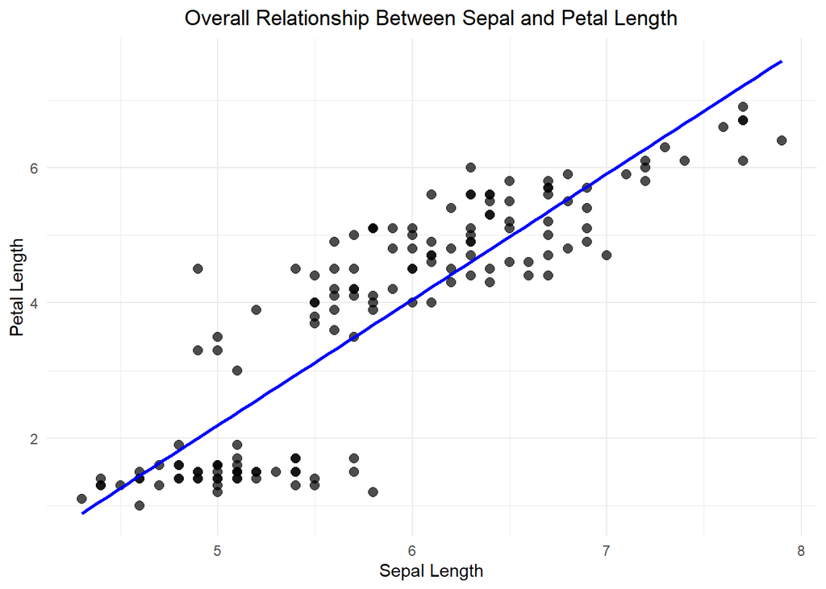

However, we might instead want to know what this relationship is for each of the individual species. To do so, we would fit three separate models. We saw above that the three iris species contained in the `iris` dataset are *setosa*, *versicolor*, and *virginica*. These names will become the items in our vector, and we will call our index variable `species_name`.

```r
# create empty list to store out from each model
models <- list()

# fit a model for each species
for (species_name in c("setosa", "versicolor", "virginica")) {

  # filter data to single species
  species_data <- iris |> filter(Species == species_name)

  # estimate model
  model <- lm(Petal.Length ~ Sepal.Length, data = species_data)

  # store results
  models[[species_name]] <- model

}
```

There are several steps inside this loop. For each of the three species in `iris`, R:

1. Selects the observations belonging to that species (using `filter`)
2. Fits a linear regression model (using `lm`)
3. Stores the resulting model inside a list (called `models`)

**NOTE**

The `for` loop is not simply performing one calculation repeatedly and overwriting the past results. Instead, it is carrying out a sequence of operations for each species and storing the result before beginning the following loop.

The resultant `models` object is a list containing three items - the linear model outputs for each of the three iris species. In other words, each element of `models` is a complete R model object. We can then access each element using `[[double brackets]]`

```r
# relationship between sepal and petal length for setosa species
models[["setosa"]]$coefficients
```

```
 (Intercept) Sepal.Length
   0.8030518    0.1316317
```

```r
# relationship between sepal and petal length for versicolor species
models[["versicolor"]]$coefficients
```

```
 (Intercept) Sepal.Length
   0.1851155    0.6864698
```

```r
# relationship between sepal and petal length for virginica species
models[["virginica"]]$coefficients
```

```
 (Intercept) Sepal.Length
   0.6104680    0.7500808
```

By filtering the `iris` data by species and running separate linear models, we gain a much more nuanced understanding of the 1.86 coefficient obtained when modelling the full data. Specifically, we find that the average association between sepal and petal length is 0.13 for *setosa*, 0.69 for *versicolor*, and 0.75 for *virginica*.

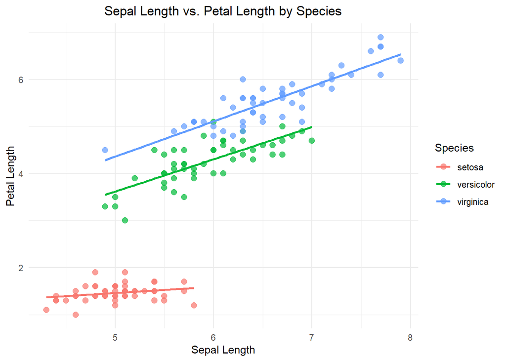

## When to use a `for` Loop

The `iris` example illustrates an important principle - you should not use a `for` loop simply because you need to perform an operation multiple times.

For example, if we only wanted to calculate the mean petal length for each species, we would be better off using the `group_by` function from `tidyverse`.

```r
iris |>

  # group the data by species
  group_by(Species) |>

  # return mean petal length within each group
  summarise(mean_petal_length = mean(Petal.Length, na.rm = TRUE)) |>

  # print output in clean table
  gt()
```

| Species | mean_petal_length |
| --- | --- |
| setosa | 1.462 |
| versicolor | 4.260 |
| virginica | 5.552 |

This is simpler than writing a `for` loop.

A `for` loop becomes more useful when each iteration involves a procedure rather than a single calculation. Some situations where loops can be useful include:

- Fitting a model separately for many groups
- Running a simulation many times
- Performing several processing steps on each input
- Using conditional logic during each iteration
- Storing complex objects such as models or plots
- Performing an operation where the result of one iteration affects the next

Thus, the key question is not *do I need to do something more than once?* but rather *would repeating a sequence of operations with a loop make this analysis clearer or easier to automate?*

**TIP**

If the task is a simple calculation that R can perform efficiently on a vector or grouped dataframe, a vectorized or grouped approach may be preferable.

If each iteration involves several steps, conditional decisions, or a complex object, a `for` loop may be a good choice.